# Base_de_datos_evidencia_2

## Diseño de BD para análisis / Evidencia 2

Equipo música 1

```python
import pandas as pd
import numpy as np
import matplotlib.pyplot as plt


df = pd.read_csv("/content/respuestas.csv", encoding='latin1')
```

```python
print(df.columns)
```

```
Index(['ID',
       'Al continuar, confirmas que leste este aviso y aceptas participar de forma voluntaria.',
       'Gnero', 'ÀEn qu rango de edad te encuentras?',
       'ÀCul es tu ocupacin?', 'ÀEn qu regin de la republica vives?',
       'ÀCmo escuchas msica principalmente?',
       'ÀCules son los gneros que escuchas con ms frecuencia?',
       'ÀQu idiomas tienen las canciones que ms escuchas?',
       'Die With A Smile de Lady Gaga, Bruno Mars',
       'Stateside + Zara Larsson de PinkPantheress, Zara Larsson',
       'So Easy (To Fall In Love) de Olivia Dean', 'Man I Need de Olivia Dean',
       'APT de ROS, Bruno Mars',
       'Everybody Wants To Rule The World de Tears For Fears',
       'Sweet Child O' Mine de Guns N' Roses', 'Highway to Hell de AC/DC',
       'Have You Ever Seen The Rain de Creedence Clearwater Revival',
       'My demons de Starset',
       'Outside (feat. Ellie Goulding) de Calvin Harris',
       'Play Hard (feat. Ne-Yo & Akon) de David Guetta, Ne-Yo, Akon',
       'Around the World de Daft Punk',
       'I'm an Albatraoz de AronChupa, Little Sis Nora',
       'Heroes (we could be) de Alesso, Tove Lo',
       'dao de  Peso Pluma, Tito Double P',
       'COQUETA de Fuerza Regida, Grupo Frontera',
       'Ya Borracho de Herencia De Grandes', 'Pvta Luna de Neton Vega',
       'Todo Lo Fue de Lenin Ramrez', 'DtMF de Bad Bunny',
       'Cuando No Era Cantante de El Bogueto, Yung Beef',
       'Me Rehso de Danny Ocean', 'In Da Getto de J Balvin, Skrillex',
       'Llamado de emergencia de Daddy Yankee',
       'let it breathe (feat. Roddy Ricch) de Gunna, Roddy Ricch',
       'Goddard Song de Lil Uzi Vert', 'Topanga de Trippie Redd',
       'WRONG (feat. Lil Mosey) de The Kid LAROI, Lil Mosey',
       'Hard Work Pays Off de Future, Juice WRLD'],
      dtype='object')
```

Se visualizaron las columnas del excel (csv), el cual, se obtuvo por medio de la encuesta.

```python
df = df.rename(columns={

    'Al continuar, confirmas que leste este aviso y aceptas participar de forma voluntaria.': 'consentimiento',
    'Gnero': 'genero',
    'ÀEn qu rango de edad te encuentras?': 'edad',
    'ÀCul es tu ocupacin?': 'ocupacion',
    'ÀEn qu regin de la republica vives?': 'region',
    'ÀCmo escuchas msica principalmente?': 'forma_escucha',
    'ÀCules son los gneros que escuchas con ms frecuencia?': 'generos_frecuentes',
    'ÀQu idiomas tienen las canciones que ms escuchas?': 'idiomas_musica',

    'Die With A Smile de Lady Gaga, Bruno Mars': 'cancion_01',
    'Stateside + Zara Larsson de PinkPantheress, Zara Larsson': 'cancion_02',
    'So Easy (To Fall In Love) de Olivia Dean': 'cancion_03',
    'Man I Need de Olivia Dean': 'cancion_04',
    'APT de ROS, Bruno Mars': 'cancion_05',
    'Everybody Wants To Rule The World de Tears For Fears': 'cancion_06',
    'Sweet Child O\' Mine de Guns N\' Roses': 'cancion_07',
    'Highway to Hell de AC/DC': 'cancion_08',
    'Have You Ever Seen The Rain de Creedence Clearwater Revival': 'cancion_09',
    'My demons de Starset': 'cancion_10',
    'Outside (feat. Ellie Goulding) de Calvin Harris': 'cancion_11',
    'Play Hard (feat. Ne-Yo & Akon) de David Guetta, Ne-Yo, Akon': 'cancion_12',
    'Around the World de Daft Punk': 'cancion_13',
    'I\'m an Albatraoz de AronChupa, Little Sis Nora': 'cancion_14',
    'Heroes (we could be) de Alesso, Tove Lo': 'cancion_15',
    'dao de  Peso Pluma, Tito Double P': 'cancion_16',
    'COQUETA de Fuerza Regida, Grupo Frontera': 'cancion_17',
    'Ya Borracho de Herencia De Grandes': 'cancion_18',
    'Pvta Luna de Neton Vega': 'cancion_19',
    'Todo Lo Fue de Lenin Ramrez': 'cancion_20',
    'DtMF de Bad Bunny': 'cancion_21',
    'Cuando No Era Cantante de El Bogueto, Yung Beef': 'cancion_22',
    'Me Rehso de Danny Ocean': 'cancion_23',
    'In Da Getto de J Balvin, Skrillex': 'cancion_24',
    'Llamado de emergencia de Daddy Yankee': 'cancion_25',
    'let it breathe (feat. Roddy Ricch) de Gunna, Roddy Ricch': 'cancion_26',
    'Goddard Song de Lil Uzi Vert': 'cancion_27',
    'Topanga de Trippie Redd': 'cancion_28',
    'WRONG (feat. Lil Mosey) de The Kid LAROI, Lil Mosey': 'cancion_29',
    'Hard Work Pays Off de Future, Juice WRLD': 'cancion_30'
})
```

```python
print(df.columns)
```

```
Index(['ID', 'consentimiento', 'genero', 'edad', 'ocupacion', 'region',
       'forma_escucha', 'generos_frecuentes', 'idiomas_musica', 'cancion_01',
       'cancion_02', 'cancion_03', 'cancion_04', 'cancion_05', 'cancion_06',
       'cancion_07', 'cancion_08', 'cancion_09', 'cancion_10', 'cancion_11',
       'cancion_12', 'cancion_13', 'cancion_14', 'cancion_15', 'cancion_16',
       'cancion_17', 'cancion_18', 'cancion_19', 'cancion_20', 'cancion_21',
       'cancion_22', 'cancion_23', 'cancion_24', 'cancion_25', 'cancion_26',
       'cancion_27', 'cancion_28', 'cancion_29', 'cancion_30'],
      dtype='object')
```

Se reemplazaron los nombres de las variables, esto para poder analizar mucho más sencillo los datos obtenidos, para después poder visualizarlos, y con ello, estar seguros de que si se cambió correctamente.

CATÁLOGO DE CANCIONES

```python
catalogo = pd.DataFrame({

    'variable': [
        'cancion_01',
        'cancion_02',
        'cancion_03',
        'cancion_04',
        'cancion_05',
        'cancion_06',
        'cancion_07',
        'cancion_08',
        'cancion_09',
        'cancion_10',
        'cancion_11',
        'cancion_12',
        'cancion_13',
        'cancion_14',
        'cancion_15',
        'cancion_16',
        'cancion_17',
        'cancion_18',
        'cancion_19',
        'cancion_20',
        'cancion_21',
        'cancion_22',
        'cancion_23',
        'cancion_24',
        'cancion_25',
        'cancion_26',
        'cancion_27',
        'cancion_28',
        'cancion_29',
        'cancion_30'
    ],

    'cancion': [
        'Die With A Smile',
        'Stateside',
        'So Easy (To Fall In Love)',
        'Man I Need',
        'APT',
        'Everybody Wants To Rule The World',
        'Sweet Child O Mine',
        'Highway to Hell',
        'Have You Ever Seen The Rain',
        'My Demons',
        'Outside',
        'Play Hard',
        'Around the World',
        'I’m an Albatraoz',
        'Heroes (we could be)',
        'dao',
        'COQUETA',
        'Ya Borracho',
        'Pvta Luna',
        'Todo Lo Fue',
        'DtMF',
        'Cuando No Era Cantante',
        'Me Rehúso',
        'In Da Getto',
        'Llamado de emergencia',
        'let it breathe',
        'Goddard Song',
        'Topanga',
        'WRONG',
        'Hard Work Pays Off'
    ],

    'artista': [
        'Lady Gaga, Bruno Mars',
        'PinkPantheress, Zara Larsson',
        'Olivia Dean',
        'Olivia Dean',
        'ROSÉ, Bruno Mars',
        'Tears For Fears',
        'Guns N Roses',
        'AC/DC',
        'Creedence Clearwater Revival',
        'Starset',
        'Calvin Harris, Ellie Goulding',
        'David Guetta, Ne-Yo, Akon',
        'Daft Punk',
        'AronChupa, Little Sis Nora',
        'Alesso, Tove Lo',
        'Peso Pluma, Tito Double P',
        'Fuerza Regida, Grupo Frontera',
        'Herencia De Grandes',
        'Neton Vega',
        'Lenin Ramírez',
        'Bad Bunny',
        'El Bogueto, Yung Beef',
        'Danny Ocean',
        'J Balvin, Skrillex',
        'Daddy Yankee',
        'Gunna, Roddy Ricch',
        'Lil Uzi Vert',
        'Trippie Redd',
        'The Kid LAROI, Lil Mosey',
        'Future, Juice WRLD'
    ],

    'genero_cancion': [
        'Pop',
        'Pop',
        'Soul',
        'Soul',
        'Pop',
        'Rock',
        'Rock',
        'Rock',
        'Rock',
        'Rock alternativo',
        'Electrónica',
        'Electrónica',
        'Electrónica',
        'Electrónica',
        'Electrónica',
        'Regional mexicano',
        'Regional mexicano',
        'Regional mexicano',
        'Regional mexicano',
        'Regional mexicano',
        'Urbano / reguetón',
        'Urbano / reguetón',
        'Urbano / reguetón',
        'Urbano / reguetón',
        'Urbano / reguetón',
        'Hip-hop / trap',
        'Hip-hop / trap',
        'Hip-hop / trap',
        'Hip-hop / trap',
        'Hip-hop / trap'
    ]
})
```

```python
print(catalogo.head())
```

```
     variable                    cancion                       artista  \
0  cancion_01           Die With A Smile         Lady Gaga, Bruno Mars
1  cancion_02                  Stateside  PinkPantheress, Zara Larsson
2  cancion_03  So Easy (To Fall In Love)                   Olivia Dean
3  cancion_04                 Man I Need                   Olivia Dean
4  cancion_05                        APT              ROSÉ, Bruno Mars

  genero_cancion
0            Pop
1            Pop
2           Soul
3           Soul
4            Pop
```

Se llevó a cabo el cambio correspondiente para poder crear el catálogo de canciones, para después mostrar los cabezales y analizar si se cambió de forma correcta.

EXPORTAR CATALOGO

```python
catalogo.to_csv(
    'catalogo_canciones.csv',
    index=False,
    encoding='utf-8'
)
```

CAMBIO DE LAS COLUMNAS DE CANCIONES

```python
print(columnas_canciones)
```

[output not shown]

Se revisó que la columna de canciones se le cambiara cada uno de los nombres de las canciones a "cancion_0#", esto para facilitar el análisis.

```python
df[columnas_canciones] = df[columnas_canciones].apply(
    pd.to_numeric,
    errors='coerce'
)
```

```python
df_analisis = df.copy()

df_analisis[columnas_canciones] = (
    df_analisis[columnas_canciones]
    .replace(0, np.nan)
)
```

Se convirtieron en valores nulos los 0 que se obtuvieron, esto para evitar cualquier tipo de sesgo que pudiera surgir. Tomando en cuenta la siguiente escala: Los que definimos antes:

- **0** — No la conozco
- **1** — La conozco pero no me gusta
- **2** — Me es indiferente
- **3** — Me gusta
- **4** — Me gusta mucho
- **5** — Es una de mis favoritas

```python
promedios = df_analisis[columnas_canciones].mean()

print(promedios)
```

```
cancion_01    3.136364
cancion_02    3.500000
cancion_03    3.000000
cancion_04    3.200000
cancion_05    3.592593
cancion_06    4.214286
cancion_07    4.266667
cancion_08    4.136364
cancion_09    4.076923
cancion_10    3.250000
cancion_11    3.400000
cancion_12    3.416667
cancion_13    3.733333
cancion_14    3.272727
cancion_15    3.357143
cancion_16    3.565217
cancion_17    4.153846
cancion_18    3.812500
cancion_19    3.500000
cancion_20    3.200000
cancion_21    4.260870
cancion_22    3.636364
cancion_23    4.120000
cancion_24    4.133333
cancion_25    3.961538
cancion_26    2.500000
cancion_27    3.222222
cancion_28    3.200000
cancion_29    2.142857
cancion_30    3.166667
dtype: float64
```

```python
df.loc['PROMEDIO', columnas_canciones] = promedios
```

```python
display(df.tail())
```

|  | ID | consentimiento | genero | edad | ocupacion | region | forma_escucha | generos_frecuentes | idiomas_musica | cancion_01 | ... | cancion_21 | cancion_22 | cancion_23 | cancion_24 | cancion_25 | cancion_26 | cancion_27 | cancion_28 | cancion_29 | cancion_30 |
| --- | --- | --- | --- | --- | --- | --- | --- | --- | --- | --- | --- | --- | --- | --- | --- | --- | --- | --- | --- | --- | --- |
| 26 | 27.0 | He ledo el aviso de privacidad y acepto parti... | Mujer | 18Ð29 | Todas las anteriores | Centro (CDMX, Estado de Mxico, Hidalgo, Morel... | Streaming (Spotify, Apple Music, YouTubeÉ) | Pop | Espaol | 0.000000 | ... | 3.00000 | 0.000000 | 5.00 | 0.000000 | 3.000000 | 0.0 | 0.000000 | 2.0 | 1.000000 | 0.000000 |
| 27 | 28.0 | He ledo el aviso de privacidad y acepto parti... | Hombre | 18Ð29 | Todas las anteriores | Norte (Chihuahua, Coahuila, Nuevo Len, Tamaul... | Streaming (Spotify, Apple Music, YouTubeÉ) | Hip-hop / Rap | Ingls | 0.000000 | ... | 0.00000 | 5.000000 | 0.00 | 0.000000 | 3.000000 | 0.0 | 5.000000 | 5.0 | 0.000000 | 0.000000 |
| 28 | 29.0 | He ledo el aviso de privacidad y acepto parti... | Prefiero no decirlo | 18Ð29 | Estudiante | Noroeste (Baja California, Sonora, Sinaloa) | Streaming (Spotify, Apple Music, YouTubeÉ) | Rock | No me fijo en el idioma | 2.000000 | ... | 0.00000 | 2.000000 | 5.00 | 0.000000 | 5.000000 | 0.0 | 0.000000 | 0.0 | 0.000000 | 0.000000 |
| 29 | 30.0 | He ledo el aviso de privacidad y acepto parti... | Mujer | 18Ð29 | Todas las anteriores | Noroeste (Baja California, Sonora, Sinaloa) | Streaming (Spotify, Apple Music, YouTubeÉ) | Rock | Espaol | 2.000000 | ... | 0.00000 | 0.000000 | 5.00 | 0.000000 | 2.000000 | 0.0 | 2.000000 | 0.0 | 2.000000 | 0.000000 |
| PROMEDIO | NaN | NaN | NaN | NaN | NaN | NaN | NaN | NaN | NaN | 3.136364 | ... | 4.26087 | 3.636364 | 4.12 | 4.133333 | 3.961538 | 2.5 | 3.222222 | 3.2 | 2.142857 | 3.166667 |

5 rows × 39 columns

Se visualizó el cambio, esto para comprobar que se agregó de forma correcta.

EXPORTAR EL ARCHIVO A CSV

```python
df.to_csv(
    'respuestas_encuesta.csv',
    index=False,
    encoding='utf-8'
)
```

Se guardó el archivo con la columna corresponde, la cual se llamó como "respuestas encuenta" en CSV.

Canciones favoritas

```python
top10 = promedios.sort_values(ascending=False).head(10)

print(top10)
```

```
cancion_07    4.266667
cancion_21    4.260870
cancion_06    4.214286
cancion_17    4.153846
cancion_08    4.136364
cancion_24    4.133333
cancion_23    4.120000
cancion_09    4.076923
cancion_25    3.961538
cancion_18    3.812500
dtype: float64
```

VISUALIZACIÓN DE DATOS

```python
catalogo_dict = dict(
    zip(catalogo['variable'], catalogo['cancion'])
)

for codigo, promedio in top10.items():
    nombre = catalogo_dict.get(codigo, codigo)
    print(f'{nombre}: {promedio:.2f}')
```

```
Sweet Child O Mine: 4.27
DtMF: 4.26
Everybody Wants To Rule The World: 4.21
COQUETA: 4.15
Highway to Hell: 4.14
In Da Getto: 4.13
Me Rehúso: 4.12
Have You Ever Seen The Rain: 4.08
Llamado de emergencia: 3.96
Ya Borracho: 3.81
```

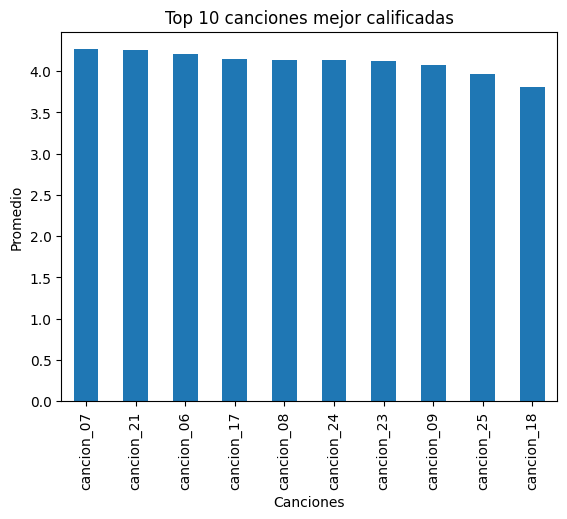

```python
top10 = promedios.sort_values(ascending=False).head(10)

top10.plot(kind='bar')

plt.title('Top 10 canciones mejor calificadas')
plt.ylabel('Promedio')
plt.xlabel('Canciones')

plt.show()
```

La tabla ayuda a analizar mejor las canciones que tuvieron un promedio mucho mayor, es decir, existe un mejor contraste de canciones y artistas.

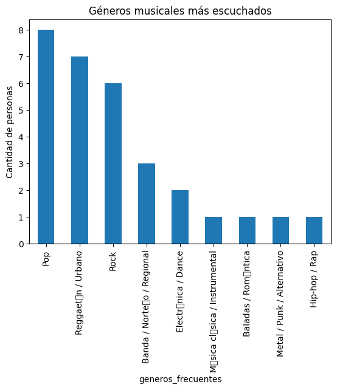

```python
df['generos_frecuentes'].value_counts().plot(kind='bar')

plt.title('Géneros musicales más escuchados')
plt.ylabel('Cantidad de personas')

plt.show()
```

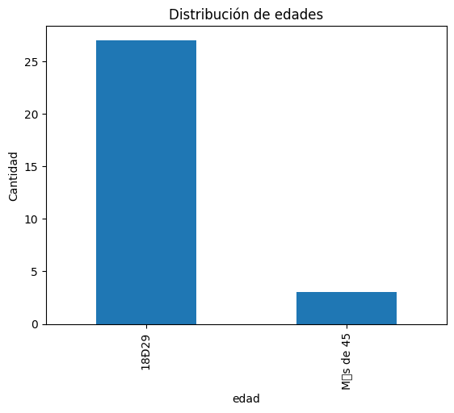

```python
df['edad'].value_counts().sort_index().plot(kind='bar')

plt.title('Distribución de edades')
plt.ylabel('Cantidad')

plt.show()
```

Esta gráfica de barras ayuda a comparar el alcance que llegó a tener la encuesta, no obstante, resultaría importante considerar algún posible sesgo (ya sea que la persona que haya contestado se equivocara y en lugar de escoger de 18 a 29 años, le puso más de 45), siendo importante a considerar en futuros análisis de datos de esta misma encuesta.

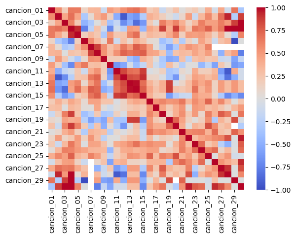

```python
import seaborn as sns

sns.heatmap(
    df_analisis[columnas_canciones].corr(),
    cmap='coolwarm'
)
```

El mapa de calor muestra las correlaciones entre las canciones evaluadas. Los colores rojos representan relaciones positivas, es decir, canciones que suelen gustar a las mismas personas, mientras que los colores azules indican relaciones negativas o diferencias en preferencias musicales. En general, se observan grupos de canciones con patrones similares de calificación, lo que permite identificar tendencias en los gustos musicales de los participantes.